# PMcode

Yuxiao Li

4/8/2020

```r
rm(list=ls())
```

# Data load

- `kriging.csv`: 기후자료와 미세먼지 자료를 병합한 데이터, 파이썬(Applicaiton_Study.ipynb)파일 실행하면 얻을 수 있음.

```r
library(sf)
```

```r
library(maps)

data_kriging <- read.csv("./kriging.csv",header = TRUE)
names(data_kriging) <- c("index","long","lat","prec","temp","pres","rh","uwind","vwind","pm25","pm25_class","pm25_log")
```

```r
dim(data_kriging)
```

```
[1] 605  12
```

# Variogram fitting

## Basic Variogram EDA

```r
library(geoR)
```

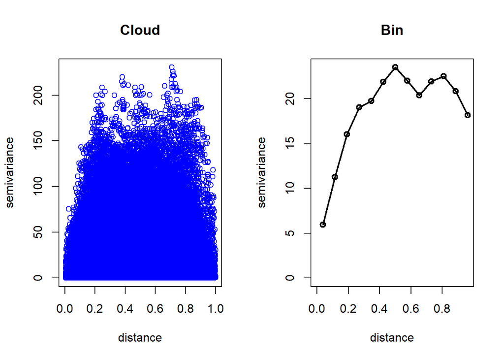

```r
vag_data <- data_kriging[,c("long","lat","pm25")]

est_vario_cloud <- variog(coords = vag_data[, 1:2], data = vag_data$pm25 , option = "cloud",
                           max.dist = 1, estimator.type='classical',message=FALSE)
est_vario_classic <- variog(coords = vag_data[, 1:2], data = vag_data$pm25 , option = "bin",
                            max.dist = 1, estimator.type='classical',message=FALSE)



par(mfrow=c(1,2))

plot(est_vario_cloud,main='Cloud',col='blue',lwd=1)

plot(est_vario_classic,main='Bin',col='blue',lwd=2)
lines(est_vario_classic,main='Bin',col='black',lwd=2)
```

max.dist를 0.9로 설정하는 것이 적절해 보입니다.

## Parametic Model fitting

### Matern Model

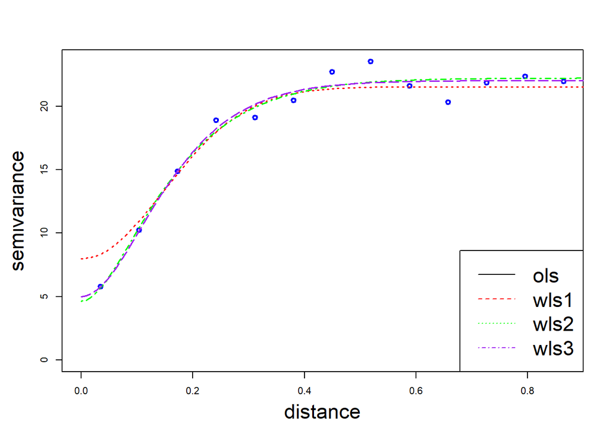

```r
md <- 0.9

est_variog <- variog(coords = vag_data[, 1:2], data = vag_data$pm25,
                     max.dist = md, estimator.type='classical', message=FALSE)
# ols 터짐
# ols=variofit(est_variog, ini=c(10, 0.3),cov.model='mat',
#             fix.kappa=FALSE, kap=1.5, nug=5, weights='equal', messages=FALSE)

wls1=variofit(est_variog, ini=c(10, 0.3), cov.model='mat',
             fix.kappa=FALSE, kap=1.5, nug=5, weights='cressie',messages=FALSE)

wls2=variofit(est_variog, ini=c(10, 0.3), cov.model='mat',
             fix.kappa=T, kap=1.5, nug=5, weights='cressie',messages=FALSE)

wls3=variofit(est_variog, ini=c(10, 0.3), cov.model='mat',
             fix.kappa=T, kap=2.5, nug=5, weights='cressie',messages=FALSE)

par(cex=0.7,cex.lab=2,cex.main=1.5,oma=c(0,1,0,0))

plot(est_variog,main='',col='blue',lwd=2)
#lines(ols,lwd=1.5)
lines(wls1,lty=3,lwd=1.5, col='red')
lines(wls2,lty=4,lwd=1.5, col='green')
lines(wls3,lty=5,lwd=1.5, col='purple')
legend('bottomright',c('ols','wls1','wls2','wls3'),
       col=c('black','red','green','purple'), lty=1:4, cex=2)
```

```r
# 추정 결과 확인
wls1
```

```
variofit: model parameters estimated by WLS (weighted least squares):
covariance model is: matern
parameter estimates:
  tausq sigmasq     phi   kappa
 7.9774 13.5587  0.0121 75.6495
Practical Range with cor=0.05 for asymptotic range: 0.3642973

variofit: minimised weighted sum of squares = 1001.614
```

```r
wls2
```

```
variofit: model parameters estimated by WLS (weighted least squares):
covariance model is: matern with fixed kappa = 1.5
parameter estimates:
  tausq sigmasq     phi
 4.6286 17.5999  0.0878
Practical Range with cor=0.05 for asymptotic range: 0.4163163

variofit: minimised weighted sum of squares = 343.7311
```

```r
wls3
```

```
variofit: model parameters estimated by WLS (weighted least squares):
covariance model is: matern with fixed kappa = 2.5
parameter estimates:
  tausq sigmasq     phi
 5.0057 17.0222  0.0646
Practical Range with cor=0.05 for asymptotic range: 0.3823023

variofit: minimised weighted sum of squares = 329.6973
```

smoothness parameter $\kappa$를 추정하는 것은 어려운 문제이기 때문에, $\kappa$를 고정하는 것이 더 적절해 보입니다. 이때, 고정할 $\kappa$값은 `variofit: minimised weighted sum of squares`의 값이 더 작은 값으로 설정하는 것이 좋을것 입니다.

하지만, Matern만 고려하는 것 보다 다양한 모형을 고려하는 것이 좋을 수 있기 때문에, 다양한 모형을 고려하여 추정을 진행해 보겠습니다.

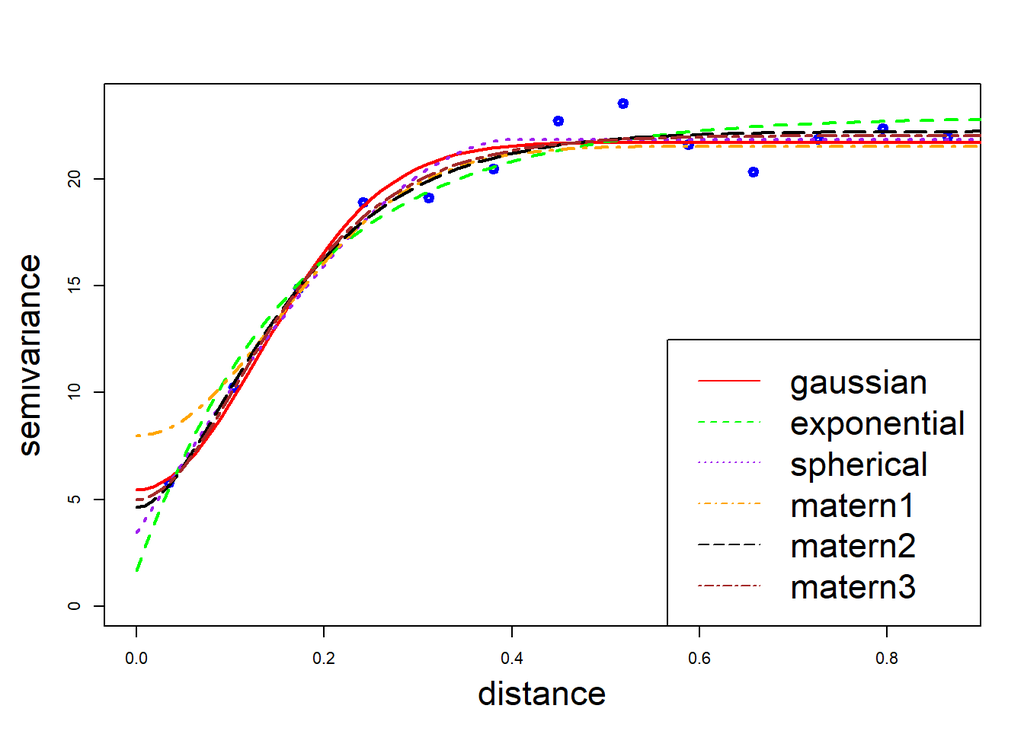

```r
# 가우시안
wls_gau=variofit(est_variog, ini=c(10, 0.3), cov.model='gaussian',
                 nug=5, weights='cressie',messages=FALSE)
# 지수
wls_exp=variofit(est_variog, ini=c(10, 0.3), cov.model='exponential',
                 nug=5, weights='cressie',messages=FALSE)
# 스페리컬
wls_sph=variofit(est_variog, ini=c(10, 0.3), cov.model='spherical',
                 nug=5, weights='cressie',messages=FALSE)

par(cex=0.7,cex.lab=2,cex.main=1.5,oma=c(0,1,0,0))

plot(est_variog,main='',col='blue',lwd=3)
lines(wls_gau,lty=1,lwd=2,col='red')
lines(wls_exp,lty=2,lwd=2,col='green')
lines(wls_sph,lty=3,lwd=2,col='purple')
lines(wls1, lty=4, lwd=2, col='orange')
lines(wls2, lty=5, lwd=2, col='black')
lines(wls3, lty=6, lwd=2, col='brown')

legend('bottomright',c('gaussian','exponential','spherical',
                       'matern1','matern2','matern3'),
       col=c('red','green','purple','orange','black','brown'), lty=1:6, cex=2)
```

```r
# 추정 결과 한번에 확인
wls_gau
```

```
variofit: model parameters estimated by WLS (weighted least squares):
covariance model is: gaussian
parameter estimates:
  tausq sigmasq     phi
 5.4533 16.2586  0.1859
Practical Range with cor=0.05 for asymptotic range: 0.3218064

variofit: minimised weighted sum of squares = 421.0874
```

```r
wls_exp
```

```
variofit: model parameters estimated by WLS (weighted least squares):
covariance model is: exponential
parameter estimates:
  tausq sigmasq     phi
 1.6603 21.2493  0.1724
Practical Range with cor=0.05 for asymptotic range: 0.5164077

variofit: minimised weighted sum of squares = 544.7207
```

```r
wls_sph
```

```
variofit: model parameters estimated by WLS (weighted least squares):
covariance model is: spherical
parameter estimates:
  tausq sigmasq     phi
 3.4421 18.4025  0.4045
Practical Range with cor=0.05 for asymptotic range: 0.4044516

variofit: minimised weighted sum of squares = 415.2668
```

```r
wls1
```

```
variofit: model parameters estimated by WLS (weighted least squares):
covariance model is: matern
parameter estimates:
  tausq sigmasq     phi   kappa
 7.9774 13.5587  0.0121 75.6495
Practical Range with cor=0.05 for asymptotic range: 0.3642973

variofit: minimised weighted sum of squares = 1001.614
```

```r
wls2
```

```
variofit: model parameters estimated by WLS (weighted least squares):
covariance model is: matern with fixed kappa = 1.5
parameter estimates:
  tausq sigmasq     phi
 4.6286 17.5999  0.0878
Practical Range with cor=0.05 for asymptotic range: 0.4163163

variofit: minimised weighted sum of squares = 343.7311
```

```r
wls3
```

```
variofit: model parameters estimated by WLS (weighted least squares):
covariance model is: matern with fixed kappa = 2.5
parameter estimates:
  tausq sigmasq     phi
 5.0057 17.0222  0.0646
Practical Range with cor=0.05 for asymptotic range: 0.3823023

variofit: minimised weighted sum of squares = 329.6973
```

Minimized weighted sum of squares값이 가장 작은 `covariance model is: matern with fixed kappa = 2.5`모형을 사용하는 것이 가장 적절해 보입니다.

# [CV] Universal Kriging(UK)

## Universal Kriging in R

Universal Kriging은 Simple, Ordinary Kriging과 다르게 Observation location과 Prediction location의 Covariate 정보까지 고려해서 Kriging을 수행하는 방법입니다. 아래 코드 블럭의 Parameter Estimation과 Kriging 수행을 위한 코드는 아래와 같습니다.

**Geodata for Universal Kriging**

Universal Kriging을 위해서는 같은 위치에서 어떤 colunm이 target(observed process)이고 어떤 colunm이 covariate인지를 명확히 해야합니다. 이때, `as.geodata()` 함수를 사용하여 `geodata` 객체를 생성합니다. 중요 옵션은 다음과 같습니다.

- `coords.col`: 위도, 경도 정보가 있는 열을 설정
- `data.col`: target이 있는 열을 설정
- `covar.col`: covariate이 있는 열을 설정

**Estimation**

여기서 Parameter Estimation은 *ML* 방법을 사용하여 $\beta$ 및 공분산 함수 모수를 추정합니다. 이때, `likfit()` 함수를 사용하여 추정을 수행합니다. 중요 옵션은 다음과 같습니다.

$$Z(s) = X(s)\boldsymbol{\beta} + \nu(s) + \epsilon(s), \; s \in D \subset
\mathbb{R}^2$$

여기서 $Z(s)$는 Obseved Process, $X(s)$는 Covariate, $\boldsymbol{\beta}$는 covariate에 대한 계수, $\nu(s)$는 Spatial process, $\epsilon(s)$는 white-noise process를 의미합니다.

- `add.to.trend`: 옵션을 사용하여 사용된 covariate를 설정합니다. 여기서는 `~prec+temp+pres+rh+uwind+vwind`로 설정하여, 모든 covariate를 사용하였습니다.

**Universal Kriging**

우선 `krige.control()` 함수를 사용하여 Kriging Object를 생성합니다. 중요 옵션은 다음과 같습니다.

- `type.krige`: Kriging 방법을 설정합니다. 여기서는 `"OK"` 즉, Ordinary Kriging을 사용하였습니다. 이때, 아래 옵션들을 사용해야 Universal Kriging을 수행할 수 있습니다.
- `trend.d`: train(observed) 데이터에 대한 Trend를 설정
- `trend.l`: valid(prediction) 데이터에 대한 Trend를 설정, 여기서 두 옵션 모두 `"1st"`로 설정하여, data에 대해서도 선형추세(평균), prediction point의 covariate에 대해서도 선형추세(평균)을 가정
- `obj.model`: Universal Kriging을 수행하기 위한 객체 모델(사용되는 모수들)을 지정

그 다음 위에서 생성한 `krige.control()` 객체를 `krige.conv()` 함수에 넣어서 Kriging을 수행합니다. 이때, 주요 옵션은 다음과 같습니다.

- `geodata`: train(observed) 데이터에 대한 `geodata` 객체
- `locations`: prediction point의 위치
- `krige`: `krige.control()` 객체를 입력 받습니다.

```r
library(geoR)
library(caret)
# caret 패키지는 confusionMatrix 함수를 사용하기 위해 설치
# 엣날 패키지라 따로 설치해야함. 구글링 필요..

# DeepKriging과 같은 CV 결과를 위한 index
test_idx <- read.csv("./test_idx.csv", header = TRUE)

# 빈벡터 생성
mse = mae = acc = c()

# start_time <- Sys.time()

# 폴드 진행
for (i in 1:10){
  cat("Fold: ",i,"\n")
    idx = na.exclude(test_idx[,i+1])

    # Train, Valid 데이터 분할
    train_kriging=data_kriging[-idx,]
    valid_kriging=data_kriging[idx,]

    # geodata 객체 생성
    geodata_train = as.geodata(train_kriging, coords.col = 2:3, data.col = 10,
                               covar.col = 4:9)
    geodata_valid = as.geodata(valid_kriging, coords.col = 2:3, data.col = 10,
                               covar.col = 4:9)


    # ML방법 Beta 및 공분산 함수 모수 추정
    geoR_fit = likfit(geodata_train, ini.cov.pars = c(18, 0.5), nugget=3,
                      cov.model = 'mat', kap=2.5, fix.kappa=T,
                      trend = trend.spatial(trend='1st', geodata = geodata_train,
                                            add.to.trend = ~prec+temp+pres+rh+uwind+vwind),
                      messages = FALSE)

    # Kriging 수행을 위한 객체 생성
    krig_control = krige.control(type.krige = "OK",
                                 trend.d = trend.spatial(trend='1st', geodata = geodata_train,
                                                         add.to.trend = ~ prec + temp + pres + rh + uwind + vwind),
                                 trend.l = trend.spatial(trend = '1st', geodata = geodata_valid,
                                                         add.to.trend = ~ prec + temp + pres + rh + uwind + vwind),
                                 obj.model = geoR_fit)

    # Kriging 수행
    result = krige.conv(geodata_train, locations = geodata_valid$coords,
                        krige=krig_control)


    mse[i] = mean((result$predict-valid_kriging[,10])^2)
    mae[i] = mean(abs(result$predict-valid_kriging[,10]))

    Pred_class <- cut(result$predict,c(-0.1,12,35.5))
    levels(Pred_class)<-c(0,1)
    acc[i] = confusionMatrix(Pred_class,as.factor(valid_kriging[,11]))$over[1]
}
```

```
Fold:  1
krige.conv: model with covariates matrix provided by the user
krige.conv: Kriging performed using global neighbourhood
Fold:  2
krige.conv: model with covariates matrix provided by the user
krige.conv: Kriging performed using global neighbourhood
Fold:  3
krige.conv: model with covariates matrix provided by the user
krige.conv: Kriging performed using global neighbourhood
Fold:  4
krige.conv: model with covariates matrix provided by the user
krige.conv: Kriging performed using global neighbourhood
Fold:  5
krige.conv: model with covariates matrix provided by the user
krige.conv: Kriging performed using global neighbourhood
Fold:  6
krige.conv: model with covariates matrix provided by the user
krige.conv: Kriging performed using global neighbourhood
Fold:  7
krige.conv: model with covariates matrix provided by the user
krige.conv: Kriging performed using global neighbourhood
Fold:  8
krige.conv: model with covariates matrix provided by the user
krige.conv: Kriging performed using global neighbourhood
Fold:  9
krige.conv: model with covariates matrix provided by the user
krige.conv: Kriging performed using global neighbourhood
Fold:  10
krige.conv: model with covariates matrix provided by the user
krige.conv: Kriging performed using global neighbourhood
```

```r
# end_time <- Sys.time()
# cat("Time: ",end_time-start_time,"\n")
```

```r
# cv결과 요약
cat("----------------[UK]---------------- \n")
```

```
----------------[UK]----------------
```

```r
cat("Mean of MSE: ",mean(mse),"\n")
```

```
Mean of MSE:  3.530463
```

```r
cat("SD of MSE: ",sd(mse),"\n")
```

```
SD of MSE:  1.021802
```

```r
cat("------------------------------------ \n")
cat("Mean of MAE: ",mean(mae),"\n")
```

```
Mean of MAE:  1.400777
```

```r
cat("SD of MAE: ",sd(mae),"\n")
```

```
SD of MAE:  0.1895963
```

```r
cat("------------------------------------ \n")
cat("Mean of Accuracy: ",mean(acc),"\n")
```

```
Mean of Accuracy:  0.8875364
```

```r
cat("SD of Accuracy: ",sd(acc),"\n")
```

```
SD of Accuracy:  0.02949751
```

```r
cat("------------------------------------ \n")
```

# [CV] Ordinary Kriging(OK): NO X(coavariate)

Ordinary Kriging은 Universal Kriging과 다르게 Covariate 정보를 사용하지 않고 Kriging을 수행하는 방법입니다.

- `likfit()` 함수를 사용하여 추정을 수행할 때, `trend` 옵션을 사용하지 않습니다.
- `krige.control()` 함수를 사용하여 Kriging Object를 생성할 때도, `trend.d`와 `trend.l` 옵션을 사용하지 않습니다.

```r
mse_nx = mae_nx = acc_nx = c()

# start_time <- Sys.time()

for (i in 1:10){
  cat("Fold: ",i,"\n")
    idx = na.exclude(test_idx[,i+1])
    train_kriging=data_kriging[-idx,]
    valid_kriging=data_kriging[idx,]

    geodata_train = as.geodata(train_kriging, coords.col = 2:3, data.col = 10)
    geodata_valid = as.geodata(valid_kriging,coords.col = 2:3,data.col = 10)

    geoR_fit = likfit(geodata_train, ini.cov.pars = c(18, 0.5), nugget=3,
                      cov.model = 'mat', kap=2.5, fix.kappa=T, messages = FALSE)
    krig_control = krige.control(type.krige = "OK",  obj.model = geoR_fit)

    result = krige.conv(geodata_train, locations = geodata_valid$coords,
                        krige=krig_control)

    mse_nx[i] = mean((result$predict-valid_kriging[,10])^2)
    mae_nx[i] = mean(abs(result$predict-valid_kriging[,10]))

    Pred_class <- cut(result$predict, c(-0.1,12,35.5))
    levels(Pred_class)<-c(0,1)
    acc_nx[i] = confusionMatrix(Pred_class,as.factor(valid_kriging[,11]))$over[1]
}
```

```
Fold:  1
krige.conv: model with constant mean
krige.conv: Kriging performed using global neighbourhood
Fold:  2
krige.conv: model with constant mean
krige.conv: Kriging performed using global neighbourhood
Fold:  3
krige.conv: model with constant mean
krige.conv: Kriging performed using global neighbourhood
Fold:  4
krige.conv: model with constant mean
krige.conv: Kriging performed using global neighbourhood
Fold:  5
krige.conv: model with constant mean
krige.conv: Kriging performed using global neighbourhood
Fold:  6
krige.conv: model with constant mean
krige.conv: Kriging performed using global neighbourhood
Fold:  7
krige.conv: model with constant mean
krige.conv: Kriging performed using global neighbourhood
Fold:  8
krige.conv: model with constant mean
krige.conv: Kriging performed using global neighbourhood
Fold:  9
krige.conv: model with constant mean
krige.conv: Kriging performed using global neighbourhood
Fold:  10
krige.conv: model with constant mean
krige.conv: Kriging performed using global neighbourhood
```

```r
end_time <- Sys.time()

# cat("Time: ",end_time-start_time,"\n")
```

```r
# 결과 요약
cat("----------------[OK]---------------- \n")
```

```
----------------[OK]----------------
```

```r
cat("Mean of MSE: ",mean(mse_nx),"\n")
```

```
Mean of MSE:  3.570255
```

```r
cat("SD of MSE: ",sd(mse_nx),"\n")
```

```
SD of MSE:  0.971181
```

```r
cat("------------------------------------ \n")
cat("Mean of MAE: ",mean(mae_nx),"\n")
```

```
Mean of MAE:  1.419185
```

```r
cat("SD of MAE: ",sd(mae_nx),"\n")
```

```
SD of MAE:  0.1641233
```

```r
cat("------------------------------------ \n")
cat("Mean of Accuracy: ",mean(acc_nx),"\n")
```

```
Mean of Accuracy:  0.8842567
```

```r
cat("SD of Accuracy: ",sd(acc_nx),"\n")
```

```
SD of Accuracy:  0.02951543
```

```r
cat("------------------------------------ \n")
```

# [CV] Simple Kriging(SK)

Simple Kriging은 Ordinary Kriging에서 평균 모수 $\beta$(강의노트 기준 $\mu$)를 추정하는 방법이 다른 Kriging 방법입니다.

- `beta` 옵션을 사용하여 평균 모수를 설정합니다. 이때, `mean(geodata_train$data)`를 사용하여 평균을 설정하였습니다.(강의노트 기준 $\bar{Z}$)

```r
mse_sk = mae_sk = acc_sk = c()

# start_time <- Sys.time()

for (i in 1:10){
  cat("Fold: ",i,"\n")
    idx = na.exclude(test_idx[,i+1])
    train_kriging_sk=data_kriging[-idx,]
    valid_kriging_sk=data_kriging[idx,]

    geodata_train_sk = as.geodata(train_kriging_sk, coords.col = 2:3, data.col = 10)
    geodata_valid_sk = as.geodata(valid_kriging_sk, coords.col = 2:3, data.col = 10)

    geoR_fit_sk = likfit(geodata_train_sk, ini.cov.pars = c(18, 0.5), nugget=3,
                      cov.model = 'mat', kap=2.5, fix.kappa=T, messages = FALSE)

    m = mean(geodata_train_sk$data)

    krig_control_sk = krige.control(type.krige = "SK", beta = m,
                                    obj.model = geoR_fit_sk)

    result_sk = krige.conv(geodata_train_sk, locations = geodata_valid_sk$coords,
                           krige=krig_control_sk)

    mse_sk[i] = mean((result_sk$predict-valid_kriging_sk[,10])^2)
    mae_sk[i] = mean(abs(result_sk$predict-valid_kriging_sk[,10]))

    Pred_class_sk <- cut(result_sk$predict, c(-0.1,12,35.5))
    levels(Pred_class_sk)<-c(0,1)
    acc_sk[i] = confusionMatrix(Pred_class_sk ,as.factor(valid_kriging_sk[,11]))$over[1]
}
```

```
Fold:  1
krige.conv: model with constant mean
krige.conv: Kriging performed using global neighbourhood
Fold:  2
krige.conv: model with constant mean
krige.conv: Kriging performed using global neighbourhood
Fold:  3
krige.conv: model with constant mean
krige.conv: Kriging performed using global neighbourhood
Fold:  4
krige.conv: model with constant mean
krige.conv: Kriging performed using global neighbourhood
Fold:  5
krige.conv: model with constant mean
krige.conv: Kriging performed using global neighbourhood
Fold:  6
krige.conv: model with constant mean
krige.conv: Kriging performed using global neighbourhood
Fold:  7
krige.conv: model with constant mean
krige.conv: Kriging performed using global neighbourhood
Fold:  8
krige.conv: model with constant mean
krige.conv: Kriging performed using global neighbourhood
Fold:  9
krige.conv: model with constant mean
krige.conv: Kriging performed using global neighbourhood
Fold:  10
krige.conv: model with constant mean
krige.conv: Kriging performed using global neighbourhood
```

```r
# end_time <- Sys.time()

# cat("Time: ",end_time-start_time,"\n")
```

```r
# 결과 요약
cat("----------------[SK]---------------- \n")
```

```
----------------[SK]----------------
```

```r
cat("Mean of MSE: ",mean(mse_sk),"\n")
```

```
Mean of MSE:  3.601329
```

```r
cat("SD of MSE: ",sd(mse_sk),"\n")
```

```
SD of MSE:  0.9756185
```

```r
cat("------------------------------------ \n")
cat("Mean of MAE: ",mean(mae_sk),"\n")
```

```
Mean of MAE:  1.424791
```

```r
cat("SD of MAE: ",sd(mae_sk),"\n")
```

```
SD of MAE:  0.1718876
```

```r
cat("------------------------------------ \n")
cat("Mean of Accuracy: ",mean(acc_sk),"\n")
```

```
Mean of Accuracy:  0.8858961
```

```r
cat("SD of Accuracy: ",sd(acc_sk),"\n")
```

```
SD of Accuracy:  0.02901581
```

```r
cat("------------------------------------ \n")
```

# Fixed Rank Kriging(FRK)

```r
# Hmisc 패키지 별도 설치 필요
# install.packages("Hmisc")

# install.packages("sp") # FRK는 sp에서 사용하는 함수가 있어서 설치해야함
# install.packages("FRK")
library(sp)
library(FRK)
```

## Data Setting

```r
# 여기서 kriging2 자료는 좌표들만 정규화 하지 않은 것입니다.
data_kriging2 <- read.csv("./kriging2.csv", header = TRUE)
names(data_kriging2) <- c("index","long","lat","prec","temp","pres","rh","uwind","vwind","pm25","pm25_class","pm25_log")

us_metero <- read.csv("./covariate0605.csv") # 기상 자료: 예측해야 할 위치
# head(us_metero)
# set.seed(123)

FRK_train <- data_kriging2[,c("long","lat","pm25")]
coordinates(FRK_train) <- ~long+lat
  # 관측 자료에서 좌표와 respose value만 SpatialPointsDataFrame으로 변환
  # 모든 covariate는 밑의 BAUs에 들어가 있어야 함
  ## 여기서 covariate는 f = pm25 ~ 1 + prec + temp + pres + rh + uwind + vwind 에서 사용되는 변수들을 의미함.

# Prediction을 위한 BAUs 생성
FRK_data_BAUs <- us_metero
coordinates(FRK_data_BAUs) <- ~long+lat
FRK_data_BAUs.grid <- BAUs_from_points(FRK_data_BAUs)
```

## Basis Setting

```r
G <- auto_basis(manifold = plane(), # 2D plane
                 data = FRK_train, # sp object data
                 nres = 3, # number of resolutions
                 type = "bisquare", # type of basis function
                 regular = 0) # place ir-regularly in domain(1: regular)

show_basis(G) + # illustrate basis functions
  coord_fixed() + # fix aspect ratio
  xlab("") + # x-label
  ylab("") # y-label
```

```
Note: show_basis assumes spherical distance functions when plotting
```

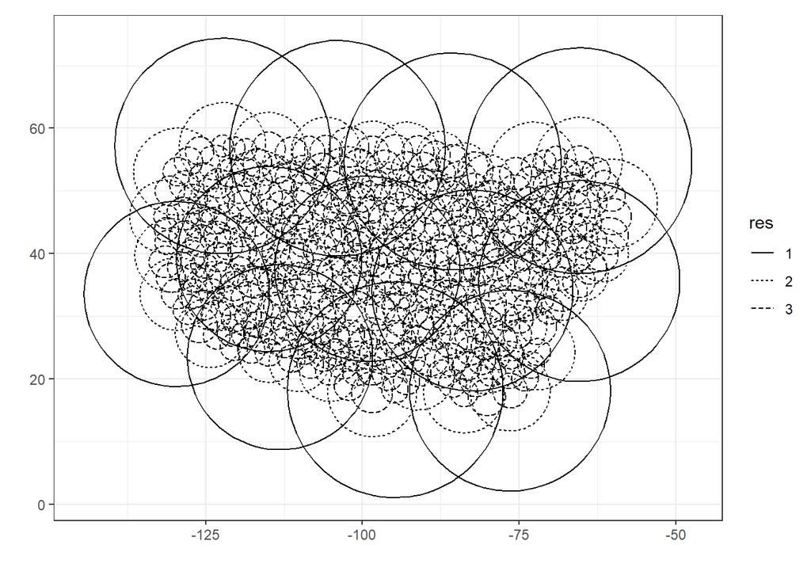

```r
show_basis(G) + # illustrate basis functions
  coord_fixed() + # fix aspect ratio
  xlab("") + # x-label
  ylab("") # y-label
```

```
Note: show_basis assumes spherical distance functions when plotting
```

[figure not shown]

## Fitting and Prediction

```r
# install.packages("gstat")
library(gstat)
f <- pm25 ~ 1 + prec + temp + pres + rh + uwind + vwind

start_time <- Sys.time()

S <- FRK(f = f,
         data = list(FRK_train),
         BAUs = FRK_data_BAUs.grid,
         method = 'TMB',
         basis = G,
         simple_kriging_fixed = FALSE,
         regular = 0)
```

```
Since method = 'TMB', setting K_type = 'precision' for computational efficiency: If you really want to use K_type = 'block-exponential' with method = 'TMB', use SRE() and SRE.fit().
Assuming fine-scale variation is homoscedastic
Modelling using 380 basis functions.
Constructing SRE model...
Fitting SRE model...
The argument taper was not specified. Since we are using method = 'TMB'
         with either i) a covariance matrix (K_type = 'block-exponential')
         or ii) irregular basis functions (object@basis@regular = 0) or iii) a
         non-plane manifold, we must use tapering for computational reasons.
         Setting taper = 3.
```

```r
Pred <- predict(S, obs_fs = FALSE)

end_time <- Sys.time()
cat("FRK Time: ",end_time-start_time,"\n")
```

```
FRK Time:  8.103275
```

## To data.frame

```r
# library(ggplot2)
BAUs_df <- as.data.frame(Pred)  # convert the BAUs to data frame
```

# [CV] FRK

```r
mse_frk = mae_frk = acc_frk = c()

# start_time <- Sys.time()

for (i in 1:10){
  cat("Fold: ",i,"\n")
    idx = na.exclude(test_idx[,i+1])
    train_kriging = data_kriging2[-idx,]
    valid_kriging = data_kriging2[idx,]

    FRK_train <- train_kriging[,c("long","lat","pm25")]
    coordinates(FRK_train) <- ~long+lat

    FRK_data_BAUs <- data_kriging2[,-c(10,11,12)]
    coordinates(FRK_data_BAUs) <- ~long+lat
    FRK_data_BAUs.grid <- BAUs_from_points(FRK_data_BAUs)

    G <- auto_basis(manifold = plane(),
                 data = FRK_train,
                 nres = 3,
                 type = "bisquare",
                 regular = 0)

    f <- pm25 ~ 1 + prec + temp + pres + rh + uwind + vwind

    S <- FRK(f = f,
             data = list(FRK_train),
             BAUs = FRK_data_BAUs.grid,
             method = 'TMB',
             basis = G,
             simple_kriging_fixed = FALSE,
             regular = 0)

    Pred <- predict(S, obs_fs = FALSE)

    FRK_Pred <- as.data.frame(Pred)
    FRK_Pred_mu <- FRK_Pred$newdata.p_mu[idx]

    mse_frk[i] = mean( (FRK_Pred_mu-valid_kriging[,10])^2 )
    mae_frk[i] = mean(abs(FRK_Pred_mu-valid_kriging[,10]))

    Pred_class <- cut(FRK_Pred_mu, c(-0.1,12,35.5))
    levels(Pred_class)<-c(0,1)
    acc_frk[i] = confusionMatrix(Pred_class,as.factor(valid_kriging[,11]))$over[1]
}
```

[output not shown]

[output cut: 55 more lines]

[output not shown]

```r
# 결과 요약
cat("----------------[FRK]---------------- \n")
```

```
----------------[FRK]----------------
```

```r
cat("Mean of MSE: ",mean(mse_frk),"\n")
```

```
Mean of MSE:  3.657424
```

```r
cat("SD of MSE: ",sd(mse_frk),"\n")
```

```
SD of MSE:  0.9876018
```

```r
cat("------------------------------------ \n")
cat("Mean of MAE: ",mean(mae_frk),"\n")
```

```
Mean of MAE:  1.427107
```

```r
cat("SD of MAE: ",sd(mae_frk),"\n")
```

```
SD of MAE:  0.1711457
```

```r
cat("------------------------------------ \n")
cat("Mean of Accuracy: ",mean(acc_frk),"\n")
```

```
Mean of Accuracy:  0.892509
```

```r
cat("SD of Accuracy: ",sd(acc_frk),"\n")
```

```
SD of Accuracy:  0.03369913
```

```r
cat("------------------------------------ \n")
```

# CV 결과 저장

```r
# 위 CV 결과들을 하나의 csv 파일로 출력
result <- data.frame("MSE UK"=mse,"MAE UK"=mae,"ACC UK"=acc,
                     "MSE OK"=mse_nx,"MAE OK"=mae_nx,"ACC OK"=acc_nx,
                     "MSE SK"=mse_sk,"MAE SK"=mae_sk,"ACC SK"=acc_sk,
                     "MSE FRK"=mse_frk,"MAE FRK"=mae_frk,"ACC FRK"=acc_frk)

write.csv(result,"./R_Krig_CV_all.csv",row.names=FALSE)

result
```

```
     MSE.UK   MAE.UK    ACC.UK   MSE.OK   MAE.OK    ACC.OK   MSE.SK   MAE.SK
1  1.952438 1.076536 0.9180328 2.091291 1.129214 0.9016393 2.046591 1.103284
2  3.888180 1.464001 0.8688525 3.865645 1.469615 0.8360656 3.894475 1.475847
3  4.243361 1.621074 0.8360656 3.987934 1.582968 0.8524590 4.003836 1.579706
4  4.210748 1.476426 0.8852459 4.538319 1.532449 0.8852459 4.578574 1.537547
5  3.576321 1.346141 0.8852459 3.497384 1.354441 0.8688525 3.532237 1.356305
6  3.459531 1.503911 0.9166667 3.422582 1.505492 0.9333333 3.576003 1.545779
7  2.364087 1.155644 0.9152542 2.511952 1.239807 0.8983051 2.510657 1.235211
8  5.136592 1.603372 0.9166667 5.206406 1.621521 0.9166667 5.199748 1.627752
9  2.318062 1.231092 0.8500000 2.541545 1.259792 0.8833333 2.609239 1.281953
10 4.155314 1.529570 0.8833333 4.039494 1.496549 0.8666667 4.061929 1.504525
      ACC.SK  MSE.FRK  MAE.FRK   ACC.FRK
1  0.9016393 2.542618 1.219826 0.9180328
2  0.8360656 3.844360 1.472654 0.8852459
3  0.8524590 4.243045 1.593951 0.8196721
4  0.8852459 4.900883 1.596696 0.8852459
5  0.8852459 3.837049 1.384908 0.9016393
6  0.9333333 3.376962 1.482258 0.9166667
7  0.8983051 2.406056 1.158999 0.9152542
8  0.9166667 5.204063 1.656202 0.9166667
9  0.8833333 2.423242 1.248516 0.8500000
10 0.8666667 3.795958 1.457062 0.9166667
```

# CV에 사용된 데이터 확인하기

```r
# 빈 데이터 프레임 생성
vc_data = data.frame(matrix(NA, nrow = 61, ncol = 20))
names(vc_data) <- c("fold 1 pm 25", "fold 1 pm class", "flod 2 pm 25", "fold 2 pm class", "fold 3 pm 25", "fold 3 pm class", "fold 4 pm 25", "fold 4 pm class", "fold 5 pm 25", "fold 5 pm class", "fold 6 pm 25", "fold 6 pm class", "fold 7 pm 25", "fold 7 pm class", "fold 8 pm 25", "fold 8 pm class", "fold 9 pm 25", "fold 9 pm class", "fold 10 pm 25", "fold 10 pm class")

# 데이터 프레임에 데이터 삽입
for (i in 1:10){
    idx = na.exclude(test_idx[,i+1])
    valid_kriging = data_kriging2[idx,]
    # 데이터의 길이가 61이면 그대로 넣고, 60이면 마지막에 NA를 붙여서 넣기
    if (nrow(valid_kriging) == 61){
        vc_data[,2*i-1] = valid_kriging[,10]
        vc_data[,2*i] = valid_kriging[,11]
    } else {
        vc_data[,2*i-1] = c(valid_kriging[,10],rep(NA,61-nrow(valid_kriging)))
        vc_data[,2*i] = c(valid_kriging[,11],rep(NA,61-nrow(valid_kriging)))
    }

}

vc_data
```

```
   fold 1 pm 25 fold 1 pm class flod 2 pm 25 fold 2 pm class fold 3 pm 25
1      5.020834               0     1.908333               0     3.669444
2      3.994907               0     8.929166               0     5.939131
3      8.520834               0    12.204166               1     4.612500
4      6.245833               0     2.989410               0     4.316667
5      6.837500               0    14.041666               1     6.505556
6      4.600000               0     7.733333               0     1.725000
7      7.245833               0    11.908333               0     9.604348
8     11.912500               0     3.800000               0    12.520834
9      9.728472               0    12.408333               1    10.400000
10    11.300000               0    12.855161               1     8.000000
11     9.543750               0     5.999907               0     6.325000
12     3.300000               0     8.018750               0     2.100000
13     2.800000               0    13.200000               1    16.650000
14     8.216667               0     7.745833               0    11.600000
```

[output cut: 233 more lines]

## 폴드별 PM25 시각화

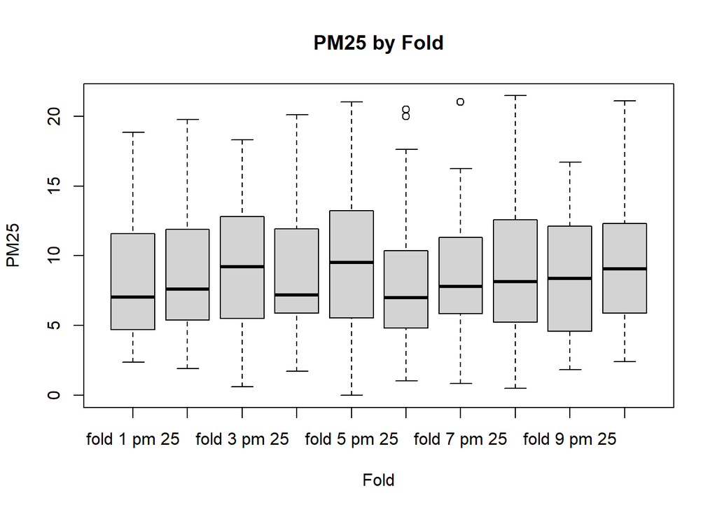

```r
# pm25만 따로 추출
vc_data_pm25 = vc_data[,c(1,3,5,7,9,11,13,15,17,19)]

# pm25 시각화
boxplot(vc_data_pm25, main="PM25 by Fold", xlab="Fold", ylab="PM25")
```

```r
# pm class만 따로 추출
vc_data_pmclass = vc_data[,c(2,4,6,8,10,12,14,16,18,20)]

# pm class 비율 계산
vc_data_pmclass_ratio = rep(9, 10)

for (i in 1:10){
  x <- na.omit(vc_data_pmclass[,i])
  vc_data_pmclass_ratio[i] = mean(x)
}

vc_data_pmclass_ratio
```

```
 [1] 0.2131148 0.2295082 0.3114754 0.2459016 0.3442623 0.1666667 0.2203390
 [8] 0.2833333 0.2500000 0.2666667
```

# Spatial Prediction

## Data Description

여기서 불러온 데이터는 파이썬에서 DeepKriging을 통해 예측한 PM25 데이터입니다. 이 데이터는 `PM25_pred_0605.csv`로 저장되어 있습니다. 이 데이터는 다음과 같은 열을 가지고 있습니다.

- `index`: 인덱스
- `long`: 경도
- `lat`: 위도
- `prec`: 강수량
- `temp`: 온도
- `pres`: 기압
- `rh`: 상대습도
- `uwind`: 풍속
- `vwind`: 풍향
- `pm25`: DeepKriging을 통해 예측된 PM25

```r
pred_data = read.csv("./PM25_pred_0605.csv")
names(pred_data)<- c("index","long","lat","prec","temp","pres","rh","uwind","vwind","pm25")
dim(pred_data)
```

```
[1] 7706   10
```

## UK

```r
geodata_train = as.geodata(data_kriging, coords.col = 2:3, data.col = 10, covar.col = 4:9)
geodata_pred = as.geodata(pred_data, coords.col = 2:3, data.col = 10, covar.col = 4:9)
```

```r
start_time <- Sys.time()

geoR_fit_UK = likfit(geodata_train, ini.cov.pars = c(18, 0.5), nugget=3,
                     cov.model = 'mat', kap=2.5, fix.kappa=T,
                     trend = trend.spatial(trend='1st', geodata = geodata_train,
                                           add.to.trend = ~prec+temp+pres+rh+uwind+vwind),
                     messages = FALSE)

krig_control_UK = krige.control(type.krige = "OK",
                             trend.d = trend.spatial(trend='1st', geodata = geodata_train,
                                                     add.to.trend = ~ prec + temp + pres + rh + uwind + vwind),
                             trend.l = trend.spatial(trend = '1st', geodata = geodata_pred,
                                                     add.to.trend = ~ prec + temp + pres + rh + uwind + vwind),
                             obj.model = geoR_fit_UK)

result_UK = krige.conv(geodata_train, locations = geodata_pred$coords,krige=krig_control_UK)
```

```
krige.conv: model with covariates matrix provided by the user
krige.conv: Kriging performed using global neighbourhood
```

```r
end_time <- Sys.time()
cat("UK Time: ",end_time-start_time,"\n")
```

```
UK Time:  27.2752
```

## OK

```r
# UK와 마찬가지로 진행

geodata_train_nx = as.geodata(data_kriging, coords.col = 2:3, data.col = 10)
geodata_pred_nx = as.geodata(pred_data, coords.col = 2:3, data.col = 10)

start_time <- Sys.time()

geoR_fit_OK = likfit(geodata_train_nx, ini.cov.pars = c(18, 0.5), nugget=3,
                  cov.model = 'mat', kap=2.5, fix.kappa=T, messages = FALSE)

krig_control_OK = krige.control(type.krige = "ok", obj.model = geoR_fit_OK)

result_OK = krige.conv(geodata_train_nx, locations = geodata_pred_nx$coords, krige=krig_control_OK)
```

```
krige.conv: model with constant mean
krige.conv: Kriging performed using global neighbourhood
```

```r
end_time <- Sys.time()
cat("OK Time: ",end_time-start_time,"\n")
```

```
OK Time:  24.81532
```

## SK

```r
m <- mean(geodata_train_nx$data)

start_time <- Sys.time()

geoR_fit_SK = likfit(geodata_train_nx, ini.cov.pars = c(18, 0.5), nugget=3,
                     cov.model = 'mat', kap=2.5, fix.kappa=T, messages = FALSE)

krig_control_SK = krige.control(type.krige = "SK", beta = m , obj.model = geoR_fit_SK)

result_SK = krige.conv(geodata_train_nx, locations = geodata_pred_nx$coords,
                       krige=krig_control_SK)
```

```
krige.conv: model with constant mean
krige.conv: Kriging performed using global neighbourhood
```

```r
end_time <- Sys.time()
cat("SK Time: ",end_time-start_time,"\n")
```

```
SK Time:  24.85753
```

## FRK

```r
# Data Setting
FRK_train <- data_kriging2[,c("long","lat","pm25")]
coordinates(FRK_train) <- ~long+lat

# Basis Setting
G <- auto_basis(manifold = plane(), # 2D plane
                 data = FRK_train, # sp object data
                 nres = 3, # number of resolutions
                 type = "bisquare", # type of basis function
                 regular = 0) # place ir-regularly in domain

# Prediction을 위한 BAUs 생성
FRK_data_BAUs <- us_metero
coordinates(FRK_data_BAUs) <- ~long+lat
FRK_data_BAUs.grid <- BAUs_from_points(FRK_data_BAUs)

f <- pm25 ~ 1 + prec + temp + pres + rh + uwind + vwind

start_time <- Sys.time()

S <- FRK(f = f,
         data = list(FRK_train),
         BAUs = FRK_data_BAUs.grid,
         method = 'TMB',
         basis = G,
         simple_kriging_fixed = FALSE,
         regular = 0)
```

```
Since method = 'TMB', setting K_type = 'precision' for computational efficiency: If you really want to use K_type = 'block-exponential' with method = 'TMB', use SRE() and SRE.fit().
Assuming fine-scale variation is homoscedastic
Modelling using 380 basis functions.
Constructing SRE model...
Fitting SRE model...
The argument taper was not specified. Since we are using method = 'TMB'
         with either i) a covariance matrix (K_type = 'block-exponential')
         or ii) irregular basis functions (object@basis@regular = 0) or iii) a
         non-plane manifold, we must use tapering for computational reasons.
         Setting taper = 3.
```

```r
Pred <- predict(S, obs_fs = FALSE)

end_time <- Sys.time()
cat("FRK Time: ",end_time-start_time,"\n")
```

```
FRK Time:  6.498571
```

## To data.frame

```r
# library(ggplot2)
BAUs_df <- as.data.frame(Pred)  # convert the BAUs to data frame
```

# Visualization

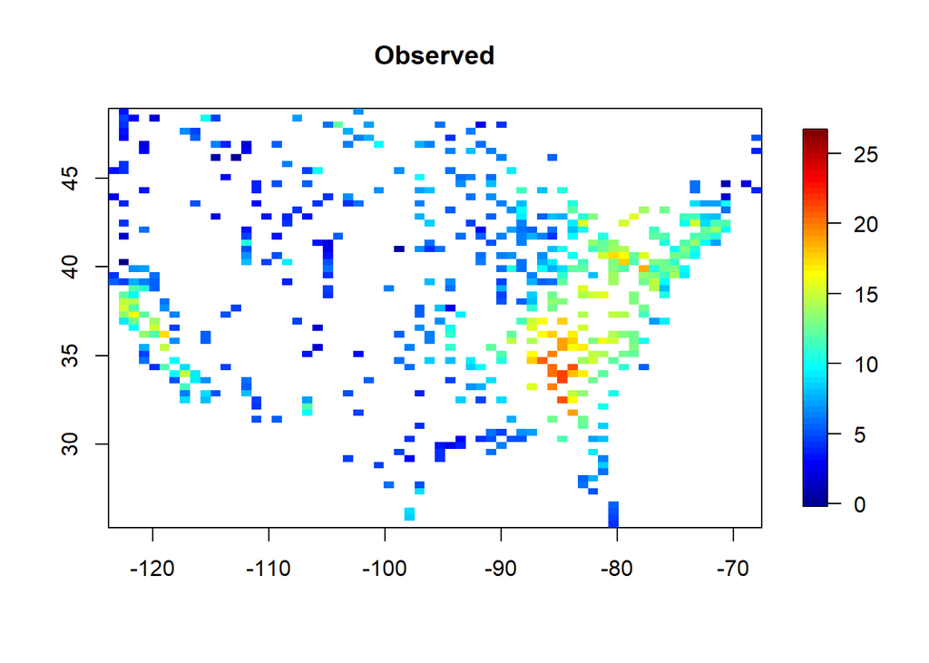

```r
# install.packages("fields")
library(fields) # 그림 그리려고 쓰는 패키지

DK_prediction <- pred_data[,10] # DeepKriging 예측값
DK_prediction_tune <- read.csv("./PM25_pred_t_0605.csv")[,10]
risk_pred <- read.csv("./PM25_pred_risk_0605.csv")[,10]

# 이미 있는 자료 활용...
pm25_data <- read.csv("./pm25_0605.csv") # 관측 자료

# pm25의 최대값
p_max = max(c(pm25_data$PM25, DK_prediction, DK_prediction_tune, result_UK$predict,
              result_OK$predict,result_SK$predict,BAUs_df$newdata.p_mu))

quilt.plot(pm25_data$Longitude, pm25_data$Latitude, pm25_data$PM25,
           zlim=c(0,p_max),main="Observed")
```

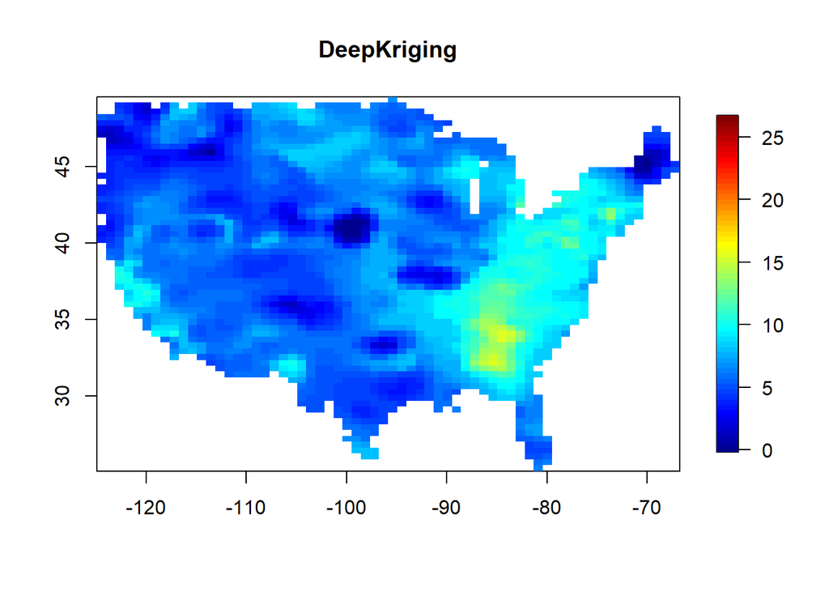

```r
quilt.plot(us_metero$long, us_metero$lat, DK_prediction, zlim=c(0,p_max),
           main="DeepKriging")
```

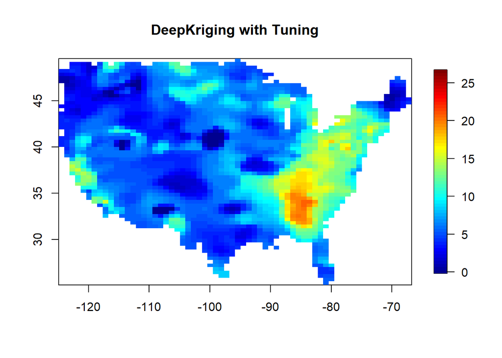

```r
quilt.plot(us_metero$long, us_metero$lat, DK_prediction_tune, zlim=c(0,p_max),
           main="DeepKriging with Tuning")
```

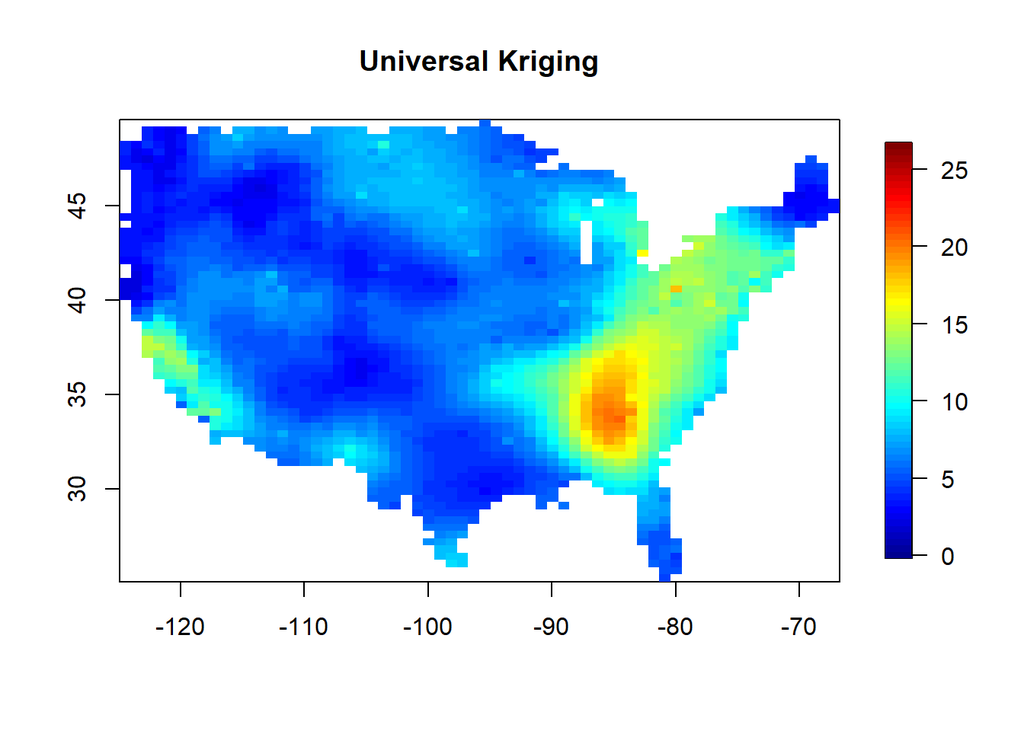

```r
quilt.plot(us_metero$long,us_metero$lat,result_UK$predict,zlim=c(0,p_max),
           main="Universal Kriging")
```

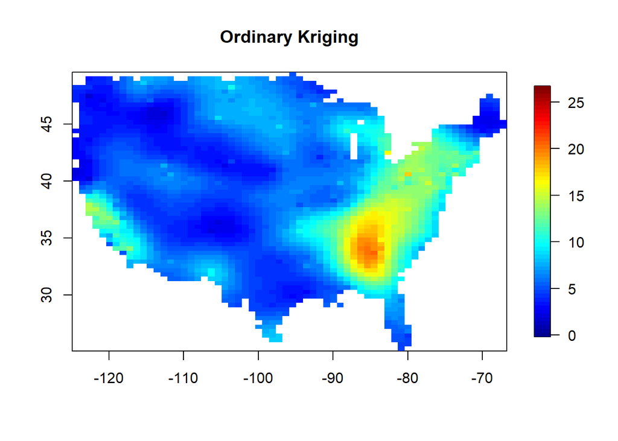

```r
quilt.plot(us_metero$long,us_metero$lat,result_OK$predict,zlim=c(0,p_max),
           main="Ordinary Kriging")
```

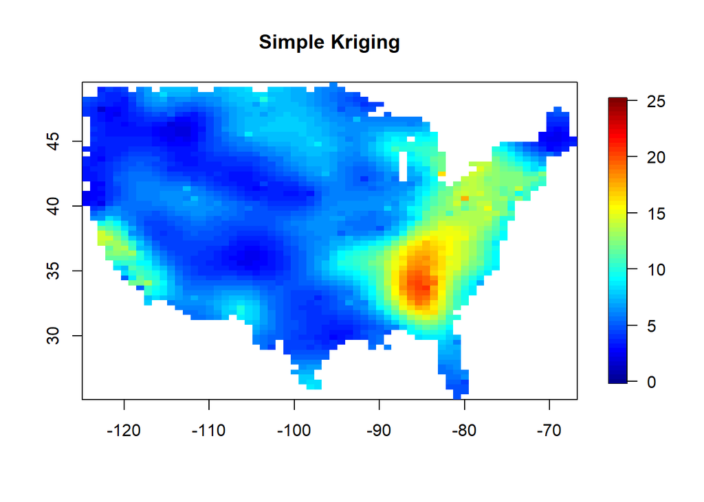

```r
quilt.plot(us_metero$long,us_metero$lat,result_SK$predict,zlim=c(0,25),
           main="Simple Kriging")
```

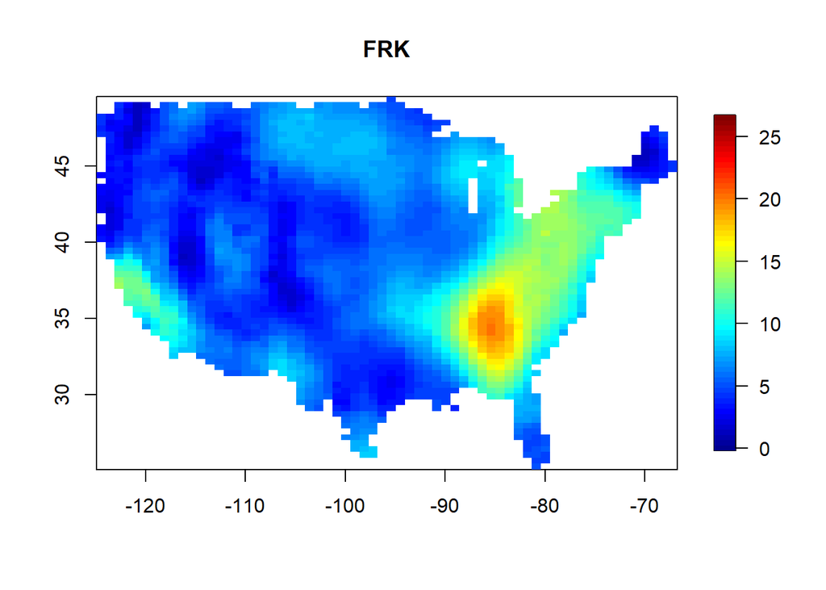

```r
quilt.plot(BAUs_df$newdata.long, BAUs_df$newdata.lat, BAUs_df$newdata.p_mu,
           zlim=c(0,p_max),main="FRK")
```

위 그림의 결과로 미루어보아 DeepKriging은 값이 낮은 지역을 좀 더 위글리 하게 맞춰서 전체적인 loss를 줄이는 방향으로 학습이 된것 같고, UK같은 경우는 관측된 지역의 값은 그대로 맞추기 때문에 값이 높은 지역에서는 DeepKriging보다 잘 맞추는 경향이 있는것 같습니다.

# Plot Kriging Predictions

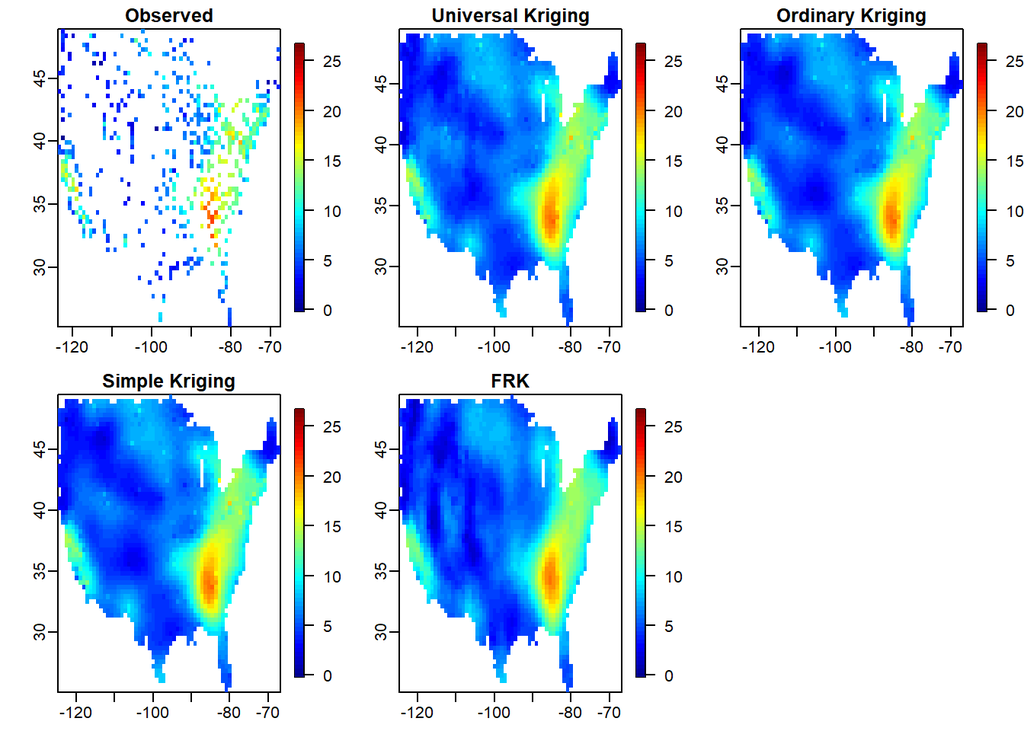

```r
# 한번에 다그리기
par(mfrow=c(2,3), mar=c(2,3,1.5,2), mgp=c(1.5,0.5,0))

# pm25의 최대값: 크리깅 예측값
krig_max = max(c(pm25_data$PM25,result_UK$predict,
              result_OK$predict,result_SK$predict,BAUs_df$newdata.p_mu))

quilt.plot(pm25_data$Longitude, pm25_data$Latitude, pm25_data$PM25,
           zlim=c(0,krig_max),main="Observed")

quilt.plot(us_metero$long, us_metero$lat, result_UK$predict,zlim=c(0,krig_max),
           main="Universal Kriging")

quilt.plot(us_metero$long,us_metero$lat,result_OK$predict,zlim=c(0,krig_max),
           main="Ordinary Kriging")

quilt.plot(us_metero$long,us_metero$lat,result_SK$predict,zlim=c(0,krig_max),
           main="Simple Kriging")

quilt.plot(BAUs_df$newdata.long, BAUs_df$newdata.lat, BAUs_df$newdata.p_mu,
           zlim=c(0,krig_max),main="FRK")
```